# Analyse de la croissance

Le taux de croissance calculé via le poids immergé permet d’etudier la croissance des coraux.

```r
SciViews::R
#import data
growth <- read("../../data/growth.rds")
# function ----
source(file = "../../R/function.R")
```

# 1 Visualisation

## 1.1 Taux de croissance

Le stress a été maintenu durant 6 jours du jour 4 au jour 10.

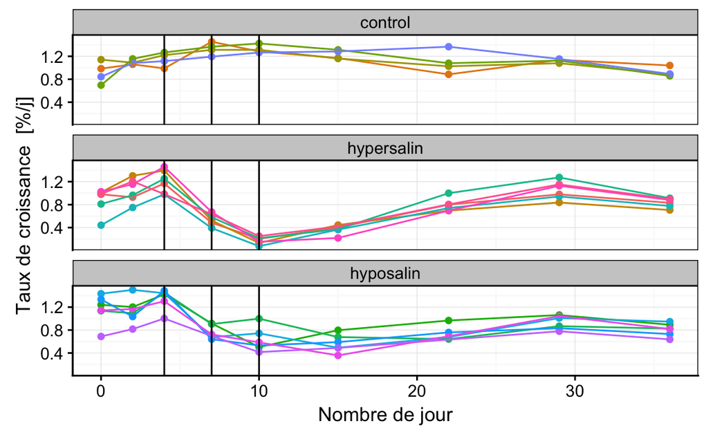

```r
growth %>.%
  filter(., ! is.na(nb_day_lag)) %>.%
  mutate(., nd = number_day-25) -> gr_visu
chart(gr_visu, formula  = g_rate_day ~ nd %col=% id) +
  geom_point(show.legend = FALSE) +
  geom_line(show.legend = FALSE) +
  geom_vline(xintercept = c(4, 7,10)) +
  facet_wrap(~ cond, nrow = 3)
```

Première visualisation des graphiques par condition.

## 1.2 Modélisation du taux de croissance

En partant du graphique ci-dessous, on réalise un modèle se basant sur un modèle polynomial d’ordre 2.

```r
# on définit le jour 4 comme point de départ
gr_visu$nd1 <- gr_visu$nd-4
# on réalise un modèle polynomiale d'ordre 2 comme point de départ
lm_control <-lm(data = gr_visu, g_rate_day ~ nd1+I(nd1^2), subset = gr_visu$cond == "control")
summary(lm_control)
```

```
Call:
lm(formula = g_rate_day ~ nd1 + I(nd1^2), data = gr_visu, subset = gr_visu$cond ==
    "control")

Residuals:
     Min       1Q   Median       3Q      Max
-0.34782 -0.03294  0.01215  0.07753  0.25822

Coefficients:
              Estimate Std. Error t value Pr(>|t|)
(Intercept)  1.1365619  0.0302572  37.563  < 2e-16 ***
nd1          0.0223547  0.0057091   3.916 0.000427 ***
I(nd1^2)    -0.0009457  0.0002000  -4.730 4.08e-05 ***
---
Signif. codes:
0 ‘***’ 0.001 ‘**’ 0.01 ‘*’ 0.05 ‘.’ 0.1 ‘ ’ 1

Residual standard error: 0.1377 on 33 degrees of freedom
Multiple R-squared:  0.4301,    Adjusted R-squared:  0.3956
F-statistic: 12.45 on 2 and 33 DF,  p-value: 9.335e-05
```

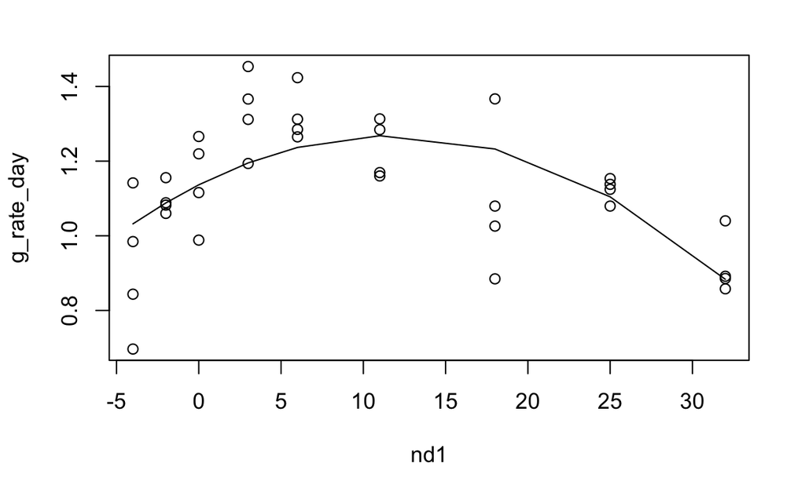

```r
plot(data = gr_visu, g_rate_day ~ nd1, subset = gr_visu$cond == "control")
lines(gr_visu$nd1[gr_visu$cond == "control"], predict(lm_control), type = "l")
```

```r
stress_recovery <- function(t, ymin, ths, thr){
  ymin + (1.1365 - ymin + 0.0224*t - 0.0009457*t^2)*(2^(-punif(t, max = 6)*6/ths) - 2^(-6/ths)*punif(t, max = 6) + (1-2^(-punif(t, min = 6, max = 106)*100/thr)))
}
# croissance au plus fort du stress, croissance du controle , croissance lors du stress, croissance lors de la récupération
# plot(-4:32, stress_recovery(-4:32,0.2,1, 3), type = "l", ylim = c(0,1.5))
# lines(-4:32, predict(lm_control, newdata = list(nd1 = -4:32)), type ="l", col = 2)
mod <- nls(data = gr_visu, g_rate_day ~ stress_recovery(nd1, ymin, ths, thr), subset = gr_visu$cond == "hypersalin", trace = TRUE, start = list(ymin = 0, ths = 2, thr = 3))
```

```
3.920932 :  0 2 3
1.673879 :  0.1798867 2.5072043 6.8861800
1.470788 :  0.1201711 3.2399557 8.5991807
1.467348 :  0.1058205 3.6000744 8.2078652
1.467172 :  0.107960 3.611661 8.293173
1.467167 :  0.107448 3.618874 8.276655
1.467166 :  0.1075446 3.6175333 8.2799128
1.467166 :  0.1075255 3.6178015 8.2792730
1.467166 :  0.1075292 3.6177493 8.2793985
```

```r
summary(mod)
```

```
Formula: g_rate_day ~ stress_recovery(nd1, ymin, ths, thr)

Parameters:
     Estimate Std. Error t value Pr(>|t|)
ymin  0.10753    0.06501   1.654    0.104
ths   3.61775    1.86582   1.939    0.058 .
thr   8.27940    1.06369   7.784 3.17e-10 ***
---
Signif. codes:
0 ‘***’ 0.001 ‘**’ 0.01 ‘*’ 0.05 ‘.’ 0.1 ‘ ’ 1

Residual standard error: 0.1696 on 51 degrees of freedom

Number of iterations to convergence: 8
Achieved convergence tolerance: 3.27e-06
```

```r
plot(data = gr_visu, g_rate_day ~ nd1, subset = gr_visu$cond == "hypersalin")
lines(gr_visu$nd1[gr_visu$cond == "hypersalin"], predict(mod), type = "l")
```

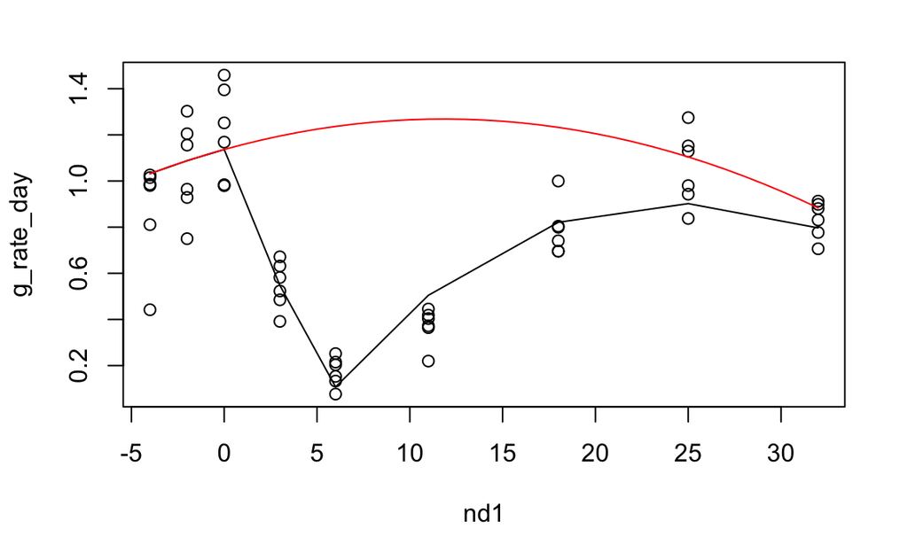

```r
lines(-4:32, predict(lm_control, newdata = list(nd1 = -4:32)), type ="l", col = 2)
```

```r
mod1 <- nls(data = gr_visu, g_rate_day ~ stress_recovery(nd1, ymin, ths, thr), subset = gr_visu$cond == "hyposalin", trace = TRUE, start = list(ymin = 0, ths = 2, thr = 3))
```

```
6.721843 :  0 2 3
2.979222 :  0.6451858 1.6766719 6.8134977
2.016276 :   0.6127132  1.7064879 16.2277857
1.948923 :   0.567418  2.096321 19.018574
1.94843 :   0.5619095  2.1848514 18.1638847
1.94841 :   0.5624832  2.1810933 18.3125361
1.948409 :   0.5623572  2.1824202 18.2898482
1.948409 :   0.5623744  2.1822389 18.2932198
1.948409 :   0.5623718  2.1822666 18.2927136
```

```r
summary(mod1)
```

```
Formula: g_rate_day ~ stress_recovery(nd1, ymin, ths, thr)

Parameters:
     Estimate Std. Error t value Pr(>|t|)
ymin   0.5624     0.0727   7.736 4.27e-10 ***
ths    2.1823     1.4493   1.506  0.13842
thr   18.2927     6.7222   2.721  0.00893 **
---
Signif. codes:
0 ‘***’ 0.001 ‘**’ 0.01 ‘*’ 0.05 ‘.’ 0.1 ‘ ’ 1

Residual standard error: 0.1974 on 50 degrees of freedom

Number of iterations to convergence: 8
Achieved convergence tolerance: 1.666e-06
```

```r
plot(data = gr_visu, g_rate_day ~ nd1, subset = gr_visu$cond == "hyposalin", ylim = c(0,1.5))
lines(gr_visu$nd1[gr_visu$cond == "hyposalin"], predict(mod1), type = "l")
```

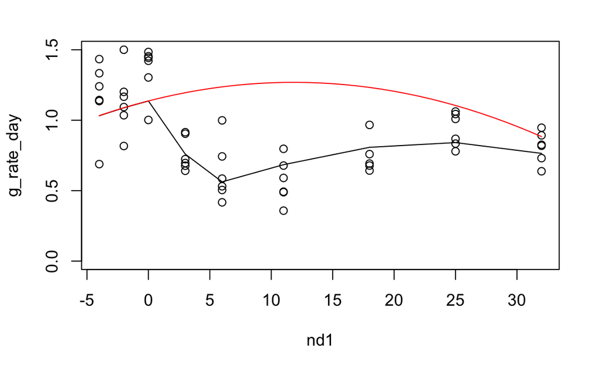

```r
lines(-4:32, predict(lm_control, newdata = list(nd1 = -4:32)), type ="l", col = 2)
```

```r
# plot(-4:32, stress_recovery(-4:32,0.2,1, 3), type = "l", ylim = c(0,1.5))
# lines(-4:32, predict(lm_control, newdata = list(nd1 = -4:32)), type ="l", col = 2)
```

# 2 Modélisation en partant des valeurs moyennes de la croissance controle.

## 2.1 Modélisation de la croissance du controle

```r
gr_visu %>.%
  filter(., cond == "control") -> gr_cont
summary(lm. <- lm(data = gr_cont, g_rate_day ~ nd))
```

```
Call:
lm(formula = g_rate_day ~ nd, data = gr_cont)

Residuals:
     Min       1Q   Median       3Q      Max
-0.47660 -0.09059  0.01401  0.12724  0.30145

Coefficients:
             Estimate Std. Error t value Pr(>|t|)
(Intercept)  1.173350   0.044955  26.101   <2e-16 ***
nd          -0.003067   0.002456  -1.249     0.22
---
Signif. codes:
0 ‘***’ 0.001 ‘**’ 0.01 ‘*’ 0.05 ‘.’ 0.1 ‘ ’ 1

Residual standard error: 0.1757 on 34 degrees of freedom
Multiple R-squared:  0.04385,   Adjusted R-squared:  0.01573
F-statistic: 1.559 on 1 and 34 DF,  p-value: 0.2203
```

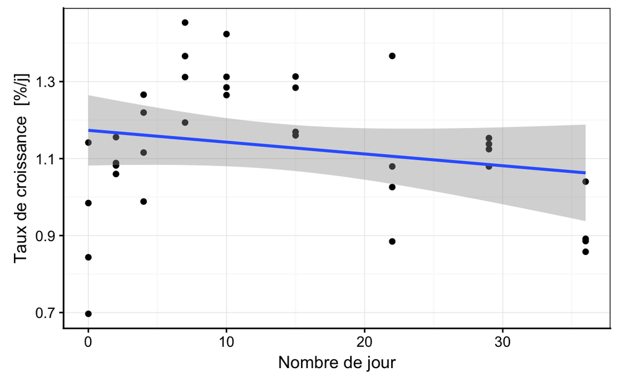

```r
lm. %>.% (function (lm, model = lm[["model"]], vars = names(model))
  chart(model, aes_string(x = vars[2], y = vars[1])) +
  geom_point() +
  stat_smooth(method = "lm", formula = y ~ x))(.)
```

On observe que la pente n’est pas significativement différent.

```r
gr_visu %>.%
  filter(., nd == 4) -> gr_acclim
anova(anova. <- lm(data = gr_acclim, g_rate_day ~ cond))
```

```
Analysis of Variance Table

Response: g_rate_day
          Df  Sum Sq  Mean Sq F value Pr(>F)
cond       2 0.11463 0.057315  1.7947  0.205
Residuals 13 0.41516 0.031936
```

Nous observons qu’au 4<sup>ième</sup> jour, il n’y a pas de différence significative entre les différents traitements. Nous soustrayons la moyenne par date du control à chaque groupe.

On va soustraire la moyenne des points du controle par jour aux points des traitements par date. Il dès lors logique d’obtenir des différence de croissance nulle pour le modèle controle.

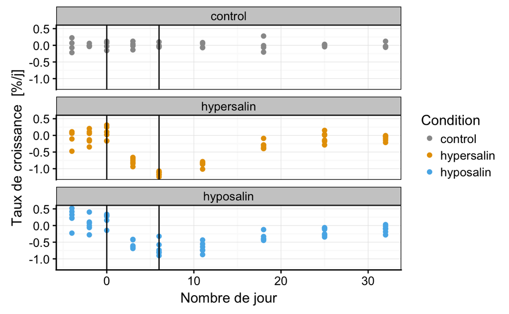

```r
gr_visu %>.%
  filter(., cond == "control") %>.%
  group_by(., number_day) %>.%
  summarise(., control_mean = mean(g_rate_day)) -> control_mean
gr_visu <- left_join(gr_visu, control_mean, by ="number_day")
gr_visu$gr_dmctrl <- gr_visu$g_rate_day - gr_visu$control_mean
chart(data = gr_visu, formula  = gr_dmctrl ~ nd1 %col=% cond) +
  geom_point() +
  facet_wrap(~ cond ,nrow =3) +
  geom_vline(xintercept = c(0, 6)) +
  scale_color_manual(values=c("#999999", "#E69F00", "#56B4E9"))
```

Les variations dans le controle expriment la variabilité de croissnce.

```r
# calculer le modele du control
lm_ctr <-lm(data = gr_visu, gr_dmctrl ~ nd1, subset = gr_visu$cond == "control")
summary(lm_ctr)
```

```
Call:
lm(formula = gr_dmctrl ~ nd1, data = gr_visu, subset = gr_visu$cond ==
    "control")

Residuals:
     Min       1Q   Median       3Q      Max
-0.21988 -0.05758 -0.01204  0.06127  0.27744

Coefficients:
              Estimate Std. Error t value Pr(>|t|)
(Intercept) -4.678e-18  2.273e-02       0        1
nd1         -1.164e-18  1.467e-03       0        1

Residual standard error: 0.105 on 34 degrees of freedom
Multiple R-squared:  3.505e-32, Adjusted R-squared:  -0.02941
F-statistic: 1.192e-30 on 1 and 34 DF,  p-value: 1
```

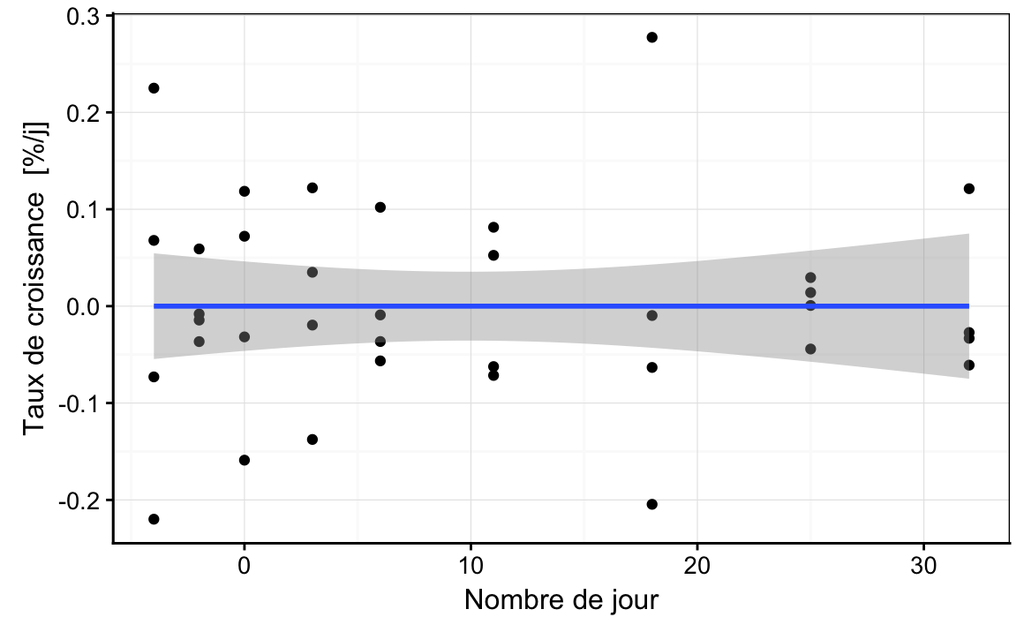

```r
gr_visu %>.%
  filter(., cond == "control") %>.%
  chart(., gr_dmctrl ~ nd1) +
  geom_point() +
  geom_smooth(method = "lm")
```

```
integer(0)
```

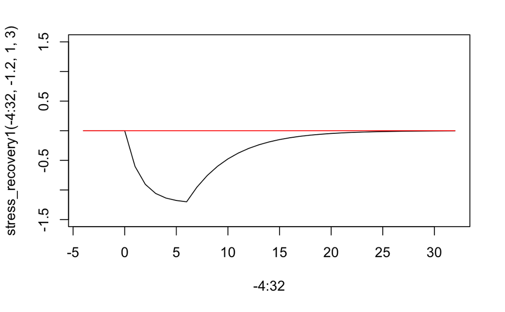

```r
stress_recovery1 <- function(t, ymin, ths, thr){
  ymin - ymin *(2^(-punif(t, max = 6)*6/ths) - 2^(-6/ths)*punif(t, max = 6) + (1-2^(-punif(t, min = 6, max = 106)*100/thr)))
}
plot(-4:32, stress_recovery1(-4:32,-1.2, 1, 3), type = "l", ylim = c(- 1.5, 1.5)) +
 lines(-4:32, predict(lm_ctr, newdata = list(nd1 = -4:32)), type ="l", col = 2)
```

```r
mod <- nls(data = gr_visu, gr_dmctrl ~ stress_recovery1(nd1, ymin, ths, thr), subset = gr_visu$cond == "hypersalin", trace = TRUE, start = list(ymin = -1.2, ths = 2, thr = 3))
```

```
2.849533 :  -1.2  2.0  3.0
1.303084 :  -1.149765  2.219715  6.401583
1.257329 :  -1.204017  2.572915  6.759762
1.257048 :  -1.206712  2.626101  6.686478
1.257041 :  -1.206220  2.623469  6.698790
1.257041 :  -1.206305  2.624080  6.696771
1.257041 :  -1.206291  2.623980  6.697103
1.257041 :  -1.206293  2.623997  6.697049
```

```r
summary(mod)
```

```
Formula: gr_dmctrl ~ stress_recovery1(nd1, ymin, ths, thr)

Parameters:
     Estimate Std. Error t value Pr(>|t|)
ymin -1.20629    0.06059 -19.909  < 2e-16 ***
ths   2.62400    0.83333   3.149  0.00274 **
thr   6.69705    0.70522   9.496 7.29e-13 ***
---
Signif. codes:
0 ‘***’ 0.001 ‘**’ 0.01 ‘*’ 0.05 ‘.’ 0.1 ‘ ’ 1

Residual standard error: 0.157 on 51 degrees of freedom

Number of iterations to convergence: 7
Achieved convergence tolerance: 1.781e-06
```

```
integer(0)
```

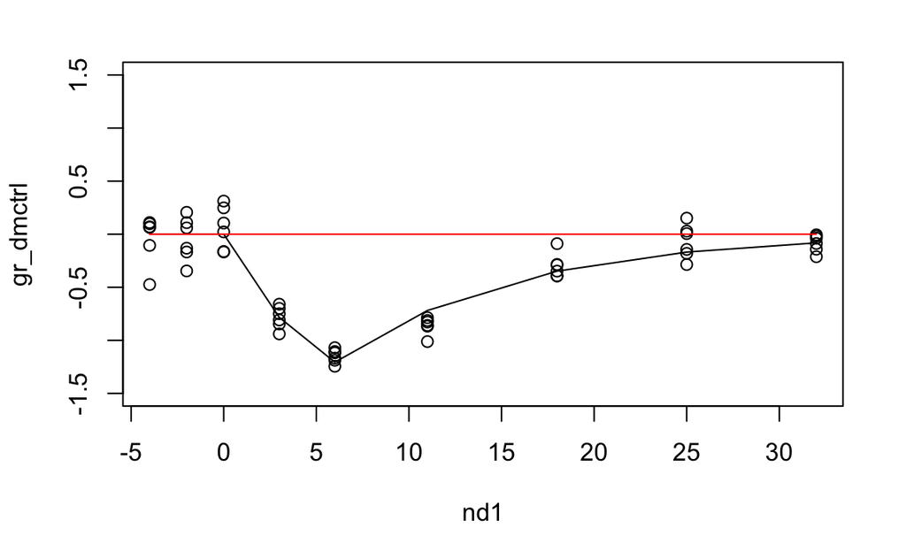

```r
plot(data = gr_visu, gr_dmctrl ~ nd1, subset = gr_visu$cond == "hypersalin", ylim = c(- 1.5, 1.5)) +
lines(gr_visu$nd1[gr_visu$cond == "hypersalin"], predict(mod), type = "l") +
lines(-4:32, predict(lm_ctr, newdata = list(nd1 = -4:32)), type ="l", col = 2)
```

```r
mod1 <- nls(data = gr_visu, gr_dmctrl ~ stress_recovery1(nd1, ymin, ths, thr), subset = gr_visu$cond == "hyposalin", trace = TRUE, start = list(ymin = -1, ths = 2, thr = 3))
```

```
4.055288 :  -1  2  3
2.501279 :  -0.682203  1.257513  7.077556
2.109868 :  -0.7311466  1.4934978 11.3449035
2.105714 :  -0.7551508  1.6423685 10.8475228
2.105659 :  -0.7540497  1.6386993 10.9356798
2.105658 :  -0.7542655  1.6400859 10.9241095
2.105658 :  -0.7542378  1.6399076 10.9256755
2.105658 :  -0.7542415  1.6399318 10.9254646
```

```r
summary(mod1)
```

```
Formula: gr_dmctrl ~ stress_recovery1(nd1, ymin, ths, thr)

Parameters:
     Estimate Std. Error t value Pr(>|t|)
ymin  -0.7542     0.0747 -10.097 1.16e-13 ***
ths    1.6399     0.8575   1.912   0.0616 .
thr   10.9255     2.3508   4.648 2.48e-05 ***
---
Signif. codes:
0 ‘***’ 0.001 ‘**’ 0.01 ‘*’ 0.05 ‘.’ 0.1 ‘ ’ 1

Residual standard error: 0.2052 on 50 degrees of freedom

Number of iterations to convergence: 7
Achieved convergence tolerance: 1.707e-06
```

```
integer(0)
```

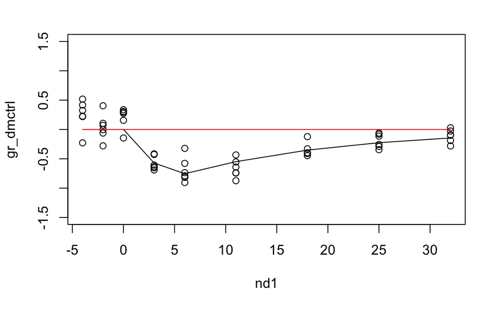

```r
plot(data = gr_visu, gr_dmctrl ~ nd1, subset = gr_visu$cond == "hyposalin", ylim = c(- 1.5, 1.5)) +
lines(gr_visu$nd1[gr_visu$cond == "hyposalin"], predict(mod1), type = "l") +
lines(-4:32, predict(lm_ctr, newdata = list(nd1 = -4:32)), type ="l", col = 2)
```

Réalisation des graphiques en utilisant chart()

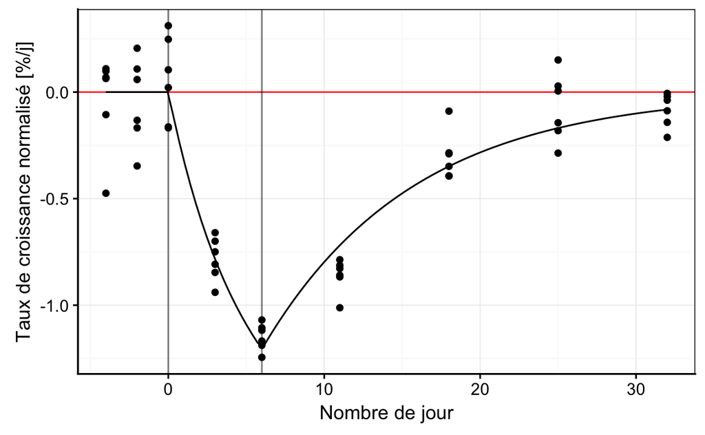

```r
gr_visu %>.%
  filter(., cond == "hypersalin") %>.%
  chart(., gr_dmctrl ~ nd1) +
  geom_hline(yintercept = 0, color = "red", alpha = 0.8) +
  geom_point() +
  stat_function(fun = predict_fun(mod)) +
  labs( y = "Taux de croissance normalisé [%/j]") +
  geom_vline(xintercept = c(0, 6), alpha = 0.5)
```

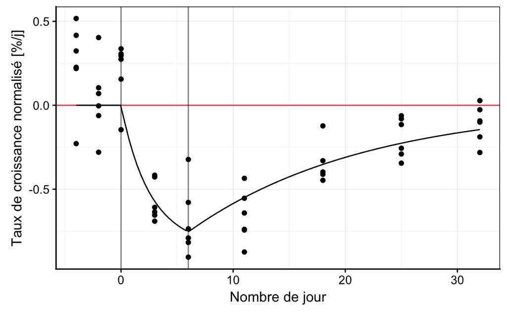

```r
gr_visu %>.%
  filter(., cond == "hyposalin") %>.%
  chart(., gr_dmctrl ~ nd1) +
  geom_hline(yintercept = 0, color = "red", alpha = 0.8) +
  geom_point() +
  stat_function(fun = predict_fun(mod1))+
  labs( y = "Taux de croissance normalisé [%/j]") +
  geom_vline(xintercept = c(0, 6), alpha = 0.5)
```

```
Removed 1 rows containing missing values (geom_point).Removed 1 rows containing missing values (geom_point).
```

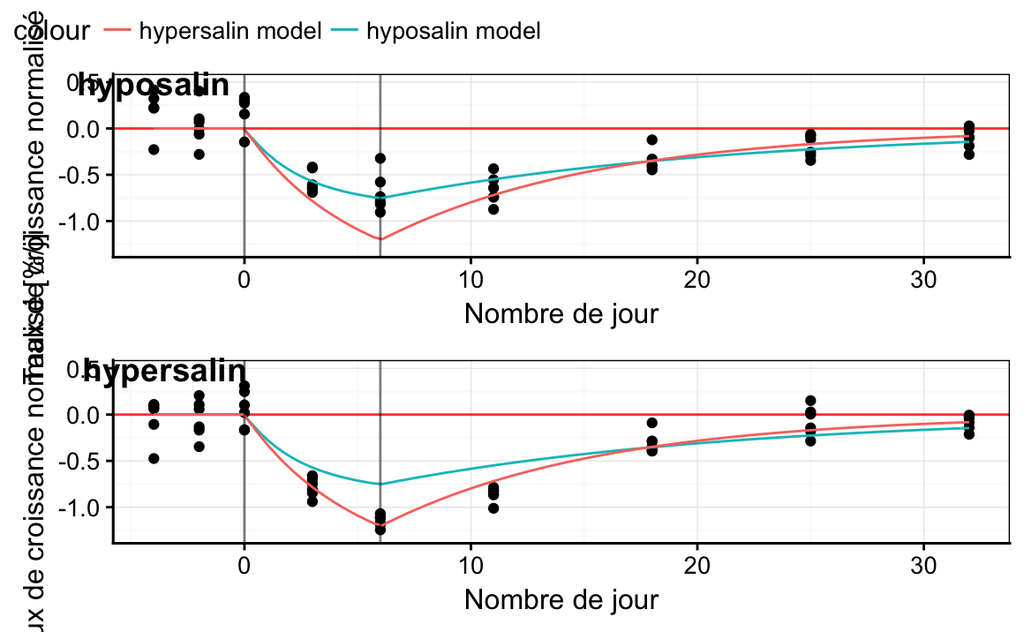

```r
gr_visu %>.%
  filter(., cond == "hyposalin") %>.%
  chart(., gr_dmctrl ~ nd1) +
  geom_hline(yintercept = 0, color = "red", alpha = 0.8) +
  geom_point() +
  stat_function(fun = predict_fun(mod1), aes(color = "hyposalin model")) +
  stat_function(fun = predict_fun(mod),  aes(color = "hypersalin model")) +
  labs( y = "Taux de croissance normalisé [%/j]") +
  geom_vline(xintercept = c(0, 6), alpha = 0.5) +
  scale_y_continuous(limits =c(-1.3, 0.5))-> a
gr_visu %>.%
  filter(., cond == "hypersalin") %>.%
  chart(., gr_dmctrl ~ nd1) +
  geom_hline(yintercept = 0, color = "red", alpha = 0.8) +
  geom_point() +
  stat_function(fun = predict_fun(mod1), aes(color = "hyposalin model")) +
  stat_function(fun = predict_fun(mod),  aes(color = "hypersalin model")) +
  labs( y = "Taux de croissance normalisé [%/j]") +
  geom_vline(xintercept = c(0, 6), alpha = 0.5) +
  scale_y_continuous(limits =c(-1.3, 0.5)) -> b
combine_charts(list(a,b),nrow = 2, labels = c("hyposalin","hypersalin"), common.legend = TRUE)
```

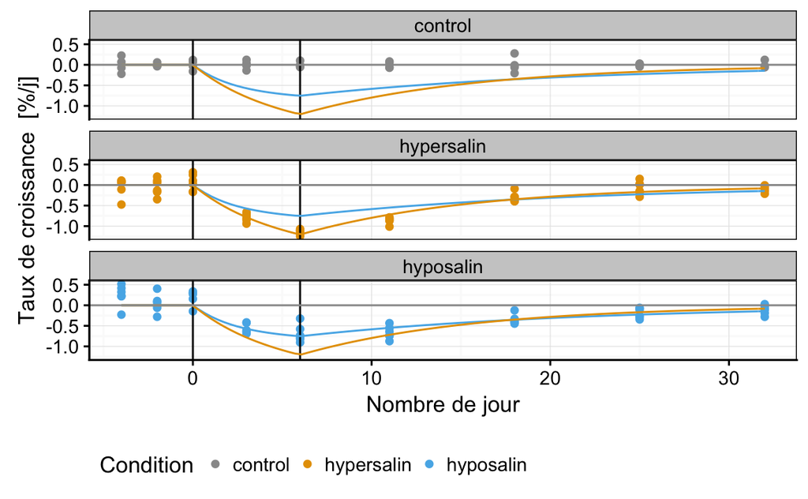

```r
chart(data = gr_visu, formula  = gr_dmctrl ~ nd1 %col=% cond) +
  geom_point() +
  facet_wrap(~ cond ,nrow =3) +
  geom_vline(xintercept = c(0, 6)) +
  scale_color_manual(values=c("#999999", "#E69F00", "#56B4E9")) +
  stat_function(fun = predict_fun(mod1), color ="#56B4E9") +
  stat_function(fun = predict_fun(mod),  color = "#E69F00") +
  geom_hline(yintercept = 0, color = "#999999") +
  theme(legend.position="bottom")
```

# 3 Division des valeurs à la moyenne des valeurs du controle par jour

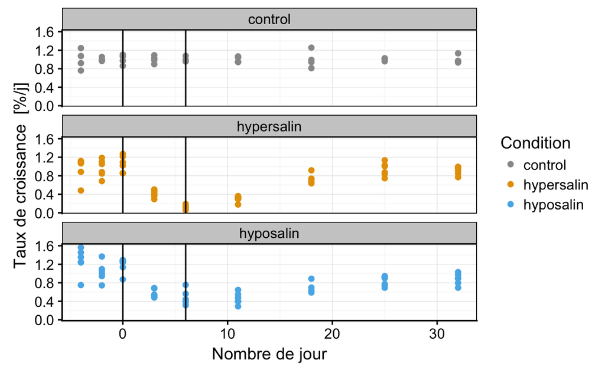

```r
gr_visu$gr_divctrl <- gr_visu$g_rate_day / gr_visu$control_mean
chart(data = gr_visu, formula  = gr_divctrl ~ nd1 %col=% cond) +
  geom_point() +
  facet_wrap(~ cond ,nrow =3) +
  geom_vline(xintercept = c(0, 6)) +
  scale_color_manual(values=c("#999999", "#E69F00", "#56B4E9"))
```

```r
# calculer le modele du control
lm_ctr <-lm(data = gr_visu, gr_divctrl ~ nd1, subset = gr_visu$cond == "control")
summary(lm_ctr)
```

```
Call:
lm(formula = gr_divctrl ~ nd1, data = gr_visu, subset = gr_visu$cond ==
    "control")

Residuals:
     Min       1Q   Median       3Q      Max
-0.23988 -0.04472 -0.01100  0.05612  0.25471

Coefficients:
             Estimate Std. Error t value Pr(>|t|)
(Intercept) 1.000e+00  2.163e-02   46.24   <2e-16 ***
nd1         4.269e-18  1.396e-03    0.00        1
---
Signif. codes:
0 ‘***’ 0.001 ‘**’ 0.01 ‘*’ 0.05 ‘.’ 0.1 ‘ ’ 1

Residual standard error: 0.09987 on 34 degrees of freedom
Multiple R-squared:  1.258e-29, Adjusted R-squared:  -0.02941
F-statistic: 4.276e-28 on 1 and 34 DF,  p-value: 1
```

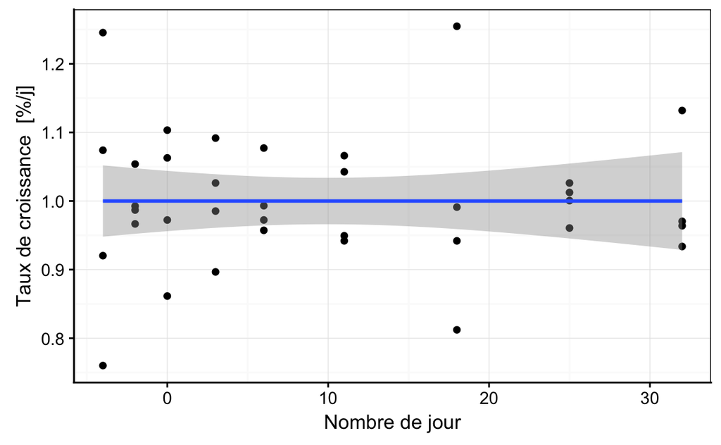

```r
gr_visu %>.%
  filter(., cond == "control") %>.%
  chart(., gr_divctrl ~ nd1) +
  geom_point() +
  geom_smooth(method = "lm")
```

```
integer(0)
```

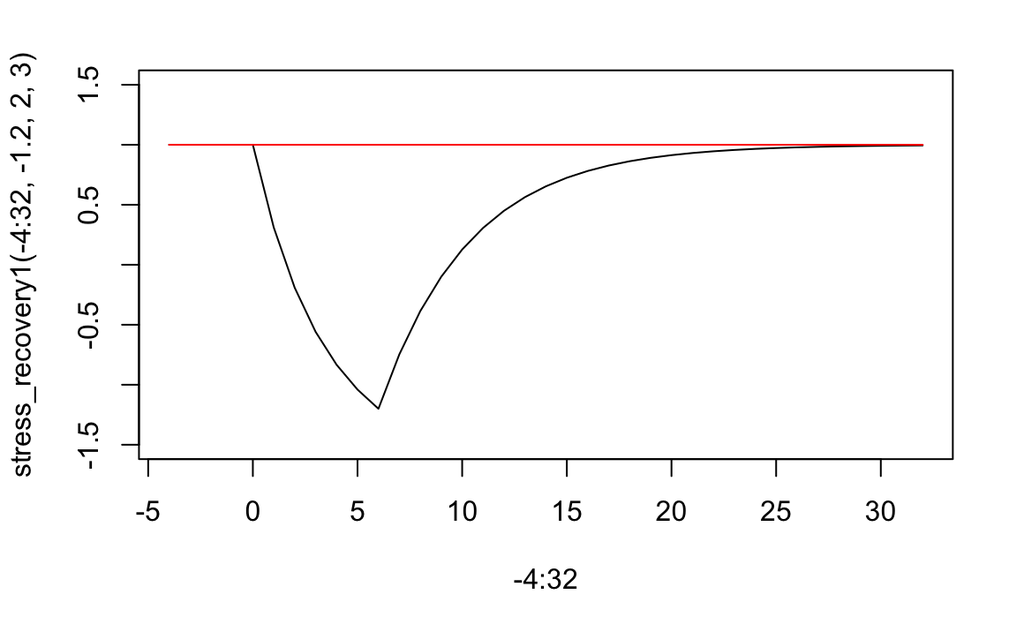

```r
stress_recovery1 <- function(t, ymin, ths, thr){
  ymin + (1 - ymin)  *(2^(-punif(t, max = 6)*6/ths) - 2^(-6/ths)*punif(t, max = 6) + (1-2^(-punif(t, min = 6, max = 106)*100/thr)))
}
plot(-4:32, stress_recovery1(-4:32,- 1.2, 2, 3), type = "l", ylim = c(- 1.5, 1.5)) +
 lines(-4:32, predict(lm_ctr, newdata = list(nd1 = -4:32)), type ="l", col = 2)
```

# 4 Modélisation avec nlsList

Objectif : Combiner les 2 conditions (hypersalin & hyposalin) en une seule modelisation grace a la fonction nlsList du package nlme.

## 4.1 nlme::nlsList()

Etape 1 : Vérifier que les paramètres obtenus pour le calcul des modèles séparés et combinés sont identiques

```r
mod <- nls(data = gr_visu, gr_divctrl ~ stress_recovery1(nd1, ymin, ths, thr), subset = gr_visu$cond == "hypersalin", trace = TRUE, start = list(ymin = 0, ths = 2, thr = 3))
```

```
2.339601 :  0 2 3
1.170526 :  0.1319735 2.2239008 6.5752151
1.092477 :  0.08351535 2.66673788 7.60277298
1.091595 :  0.07724578 2.78510956 7.40151777
1.091571 :  0.07814994 2.78006517 7.43527037
1.091571 :  0.07798824 2.78173932 7.43000367
1.091571 :  0.0780132 2.7814820 7.4308350
1.091571 :  0.07800925 2.78152281 7.43070403
```

```r
summary(mod)
```

```
Formula: gr_divctrl ~ stress_recovery1(nd1, ymin, ths, thr)

Parameters:
     Estimate Std. Error t value Pr(>|t|)
ymin  0.07801    0.05580   1.398   0.1681
ths   2.78152    1.12578   2.471   0.0169 *
thr   7.43070    0.93445   7.952 1.73e-10 ***
---
Signif. codes:
0 ‘***’ 0.001 ‘**’ 0.01 ‘*’ 0.05 ‘.’ 0.1 ‘ ’ 1

Residual standard error: 0.1463 on 51 degrees of freedom

Number of iterations to convergence: 7
Achieved convergence tolerance: 3.104e-06
```

```r
mod1 <- nls(data = gr_visu, gr_divctrl ~ stress_recovery1(nd1, ymin, ths, thr), subset = gr_visu$cond == "hyposalin", trace = TRUE, start = list(ymin = 0, ths = 2, thr = 3))
```

```
4.476998 :  0 2 3
2.391668 :  0.4868732 1.4461914 6.5265460
1.895214 :   0.4534677  1.4742559 13.0566224
1.882587 :   0.4189913  1.7536238 12.8459683
1.882575 :   0.4192961  1.7634081 12.8860654
1.882575 :   0.4192361  1.7639870 12.8810538
1.882575 :   0.4192436  1.7639204 12.8816889
```

```r
summary(mod1)
```

```
Formula: gr_divctrl ~ stress_recovery1(nd1, ymin, ths, thr)

Parameters:
     Estimate Std. Error t value Pr(>|t|)
ymin  0.41924    0.06929   6.051 1.82e-07 ***
ths   1.76392    1.14128   1.546 0.128517
thr  12.88169    3.47284   3.709 0.000522 ***
---
Signif. codes:
0 ‘***’ 0.001 ‘**’ 0.01 ‘*’ 0.05 ‘.’ 0.1 ‘ ’ 1

Residual standard error: 0.194 on 50 degrees of freedom

Number of iterations to convergence: 6
Achieved convergence tolerance: 3.277e-06
```

```r
# modelisation avec nlsList
nlme::nlsList(data = gr_visu, gr_divctrl ~ stress_recovery1(nd1, ymin, ths, thr) | cond, subset = gr_visu$cond %in% c("hypersalin", "hyposalin"), start = list(ymin = 0, ths = 2, thr = 3)) -> mod2
summary(mod2)
```

```
Call:
  Model: gr_divctrl ~ stress_recovery1(nd1, ymin, ths, thr) | cond
   Data: gr_visu

Coefficients:
   ymin
             Estimate Std. Error  t value     Pr(>|t|)
hypersalin 0.07800925 0.06544599 1.191964 1.681298e-01
hyposalin  0.41924356 0.06127299 6.842224 1.823787e-07
   ths
           Estimate Std. Error  t value   Pr(>|t|)
hypersalin 2.781523   1.320481 2.106446 0.01686538
hyposalin  1.763920   1.009304 1.747660 0.12851707
   thr
            Estimate Std. Error  t value     Pr(>|t|)
hypersalin  7.430704   1.096066 6.779433 1.727387e-10
hyposalin  12.881689   3.071239 4.194298 5.219246e-04

Residual standard error: 0.1716012 on 101 degrees of freedom
```

On peut voir que les paramètres obtenus quelque soit la methode utilisée sont les memes.

## 4.2 nlshelper::anova_nlslist()

```r
stats::nls(data = gr_visu, gr_divctrl ~ stress_recovery1(nd1, ymin, ths, thr), subset = gr_visu$cond %in% c("hypersalin", "hyposalin"), start = list(ymin = 0, ths = 2, thr = 3)) -> nlsreduc
nlme::nlsList(data = gr_visu, gr_divctrl ~ stress_recovery1(nd1, ymin, ths, thr) | cond, subset = gr_visu$cond %in% c("hypersalin", "hyposalin"), start = list(ymin = 0, ths = 2, thr = 3)) -> nlsfull
summary(nlsfull)
```

```
Call:
  Model: gr_divctrl ~ stress_recovery1(nd1, ymin, ths, thr) | cond
   Data: gr_visu

Coefficients:
   ymin
             Estimate Std. Error  t value     Pr(>|t|)
hypersalin 0.07800925 0.06544599 1.191964 1.681298e-01
hyposalin  0.41924356 0.06127299 6.842224 1.823787e-07
   ths
           Estimate Std. Error  t value   Pr(>|t|)
hypersalin 2.781523   1.320481 2.106446 0.01686538
hyposalin  1.763920   1.009304 1.747660 0.12851707
   thr
            Estimate Std. Error  t value     Pr(>|t|)
hypersalin  7.430704   1.096066 6.779433 1.727387e-10
hyposalin  12.881689   3.071239 4.194298 5.219246e-04

Residual standard error: 0.1716012 on 101 degrees of freedom
```

```r
nlshelper::anova_nlslist(nlsfull, nlsreduc) -> test
```

# 5 Réalisation des graphiques en utilisant chart()

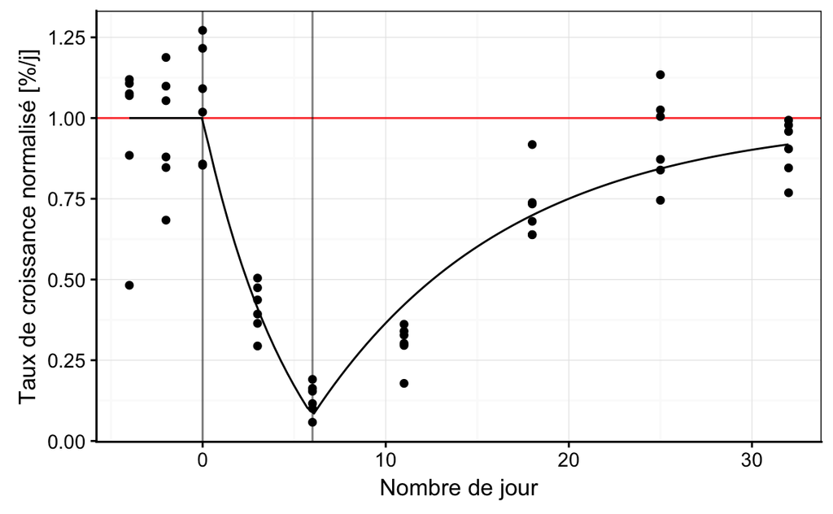

```r
gr_visu %>.%
  filter(., cond == "hypersalin") %>.%
  chart(., gr_divctrl ~ nd1) +
  geom_hline(yintercept = 1, color = "red", alpha = 0.8) +
  geom_point() +
  stat_function(fun = predict_fun(mod)) +
  labs( y = "Taux de croissance normalisé [%/j]") +
  geom_vline(xintercept = c(0, 6), alpha = 0.5)
```

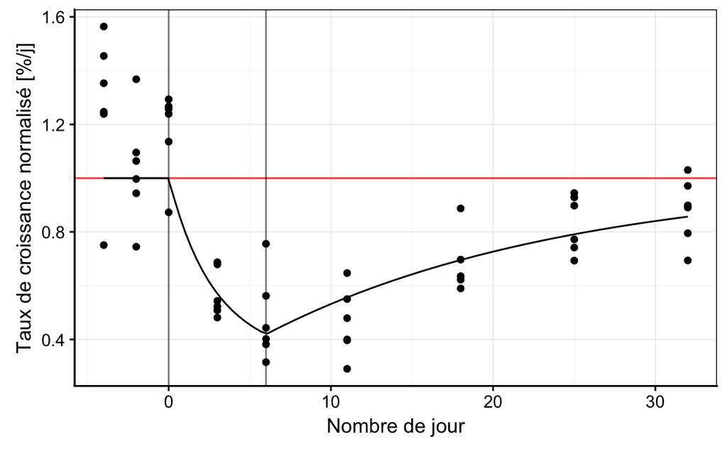

```r
gr_visu %>.%
  filter(., cond == "hyposalin") %>.%
  chart(., gr_divctrl ~ nd1) +
  geom_hline(yintercept = 1, color = "red", alpha = 0.8) +
  geom_point() +
  stat_function(fun = predict_fun(mod1))+
  labs( y = "Taux de croissance normalisé [%/j]") +
  geom_vline(xintercept = c(0, 6), alpha = 0.5)
```

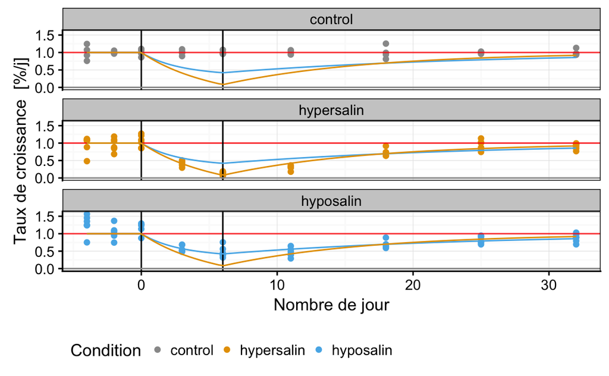

# 6 Analyse statistique

Une analyse via une série spatio-temporelle n’est pas utilisable étant donné le peu de nombre de point de mesure que nous avons. Une anova à mesure répétée est une solution envisageable. Il faut cependant que l’homoscédasticité soit respecté.

```r
bartlett.test(data = growth, g_rate_day ~ cond)
bartlett.test(data = growth, log(g_rate_day) ~ cond)
bartlett.test(data = growth, exp(g_rate_day) ~ cond)
bartlett.test(data = growth, exp(exp(exp(g_rate_day))) ~ cond)
bartlett.test(data = growth, (1/exp(g_rate_day)) ~ cond)
```

```r
anova. <- aov(data = growth, g_rate_day ~ cond*phase + Error(number_day/cond))
summary(anova.)
```

## 6.1 modèle linéaire sur la condition de controle

Une approche peut être de savoir si la croissance du controle varie au cours du temps

```r
growth %>.%
  filter(., cond == "control") %>.%
  filter(., ! is.na(g_rate_day)) %>.%
  mutate(., g_rate_exp = exp(g_rate_day))-> gr

bartlett.test(data = gr, exp(g_rate_day) ~ number_day)
bartlett.test(data = gr, exp(g_rate_day) ~ phase)
summary(gr1 <- lm(data = gr, g_rate_exp ~ number_day))
summary(gr1 <- lm(data = gr, g_rate_exp ~ number_day + I(number_day^2)))
gr1 %>.% (function (lm, model = lm[["model"]], vars = names(model))
  chart(model, aes_string(x = vars[2], y = vars[1])) +
  geom_point() +
  stat_smooth(method = "lm", formula = y ~ x + I(x^2)))(.) +
  geom_hline(yintercept = mean(exp(gr$g_rate_day)))


anova(lm. <- lm(data = gr, g_rate_day ~ number_day * phase))
anova(lm. <- lm(data = gr, g_rate_day ~ number_day * phase))
summary(lm. <- lm(data = growth, g_rate_day ~ number_day * phase *cond))
```

### 6.2.1 J-25 à J-29

```r
growth %>.%
  filter(. , number_day == 25) %>.%
  kruskal.test(data = ., g_rate_day ~ cond)
growth %>.%
  filter(. , number_day == 25) %>.%
  kruskal.test(data = ., g_rate_day ~ cond)
growth %>.%
  filter(. , number_day == 29) %>.%
  kruskal.test(data = ., g_rate_day ~ cond)
```

### 6.2.2 J-32

```r
growth %>.%
  filter(. , number_day == 32) %>.%
  kruskal.test(data = ., g_rate_day ~ cond)

summary(kw_comp. <- nparcomp::nparcomp(data = filter(growth , number_day == 32), g_rate_day ~ cond))
plot(kw_comp.)



growth %>.%
  filter(. , number_day == 35) %>.%
  kruskal.test(data = ., g_rate_day ~ cond)
summary(kw_comp. <- nparcomp::nparcomp(data = filter(growth , number_day == 35), g_rate_day ~ cond))
plot(kw_comp.)
growth %>.%
  filter(. , number_day == 40) %>.%
  kruskal.test(data = ., g_rate_day ~ cond)
summary(kw_comp. <- nparcomp::nparcomp(data = filter(growth , number_day == 40), g_rate_day ~ cond))
plot(kw_comp.)

growth %>.%
  filter(. , number_day == 47) %>.%
  kruskal.test(data = ., g_rate_day ~ cond)
summary(kw_comp. <- nparcomp::nparcomp(data = filter(growth , number_day == 47), g_rate_day ~ cond))
plot(kw_comp.)

growth %>.%
  filter(. , number_day == 54) %>.%
  kruskal.test(data = ., g_rate_day ~ cond)
summary(kw_comp. <- nparcomp::nparcomp(data = filter(growth , number_day == 54), g_rate_day ~ cond))
plot(kw_comp.)
growth %>.%
  filter(. , number_day == 61) %>.%
  kruskal.test(data = ., g_rate_day ~ cond)

summary(kw_comp. <- nparcomp::nparcomp(data = filter(growth , number_day == 61), g_rate_day ~ cond))
plot(kw_comp.)
```

### 6.2.3 J-35

## 6.3 Test de Levene et Bartlett - homoscédasticité interaction ?

```r
car::leveneTest(data =growth, exp(g_rate_day) ~ cond)
car::leveneTest(data =growth, exp(g_rate_day) ~ phase)
car::leveneTest(data =growth, exp(g_rate_day) ~ as.factor(number_day))

car::leveneTest(data = growth, exp(g_rate_day) ~ cond*phase)
car::leveneTest(data = growth, exp(g_rate_day) ~ cond*as.factor(number_day))

bartlett.test(data = growth, exp(g_rate_day) ~ interaction(cond, phase))
bartlett.test(data = growth, exp(g_rate_day) ~ interaction(cond, as.factor(number_day)))
```

## 6.4 Test de Scheirer-Ray-Hare (test Post-hoc : test de Dunn)

Equivalent non-paramétrique de l’ANOVA à deux facteurs avec répétitions

```r
# cond * number_day
rcompanion::scheirerRayHare(data = growth, formula = g_rate_day ~ cond * number_day)
## Post-hoc cond
FSA::dunnTest(growth$g_rate_day, growth$cond, method = "bh")
dunn.test::dunn.test(growth$g_rate_day, growth$cond, method="bh")
## Post-hoc number_day
FSA::dunnTest(growth$g_rate_day, as.factor(growth$number_day), method = "bh")
dunn.test::dunn.test(growth$g_rate_day, growth$number_day, method="bh", wrap = TRUE )

## Post-hoc interaction
FSA::dunnTest(growth$g_rate_day, interaction(growth$cond, growth$number_day), method = "bh") %>.%
  filter(.$res, P.adj < 0.05) %>.%
  arrange(., P.adj)

FSA::dunnTest(growth$g_rate_day, interaction(growth$cond, growth$number_day), method = "bonferroni") %>.%
  filter(.$res, P.adj < 0.05) %>.%
  arrange(., P.adj)
dunn.test::dunn.test(growth$g_rate_day, interaction(growth$cond, growth$number_day), method = "bh", table = FALSE, list = TRUE)

# cond * phase
rcompanion::scheirerRayHare(data = growth, formula = g_rate_day ~ cond * phase)
## Post-hoc phase
dunn.test::dunn.test(growth$g_rate_day, growth$phase, method="bh")

## Post-hoc interaction
FSA::dunnTest(growth$g_rate_day, interaction(growth$cond, growth$phase), method = "bh") %>.%
  filter(.$res, P.adj < 0.05) %>.%
  arrange(., P.adj)
pairwise.wilcox.test(growth$g_rate_day, interaction(growth$cond, growth$phase), method = "bh")
```